# Missing Data Lab

## Find snowfall data

I need to know how much snow fell *per day* in New York State in February 2017, on a county or more detailed level. I know some government agency measures and reports snowfall and puts the data online. Find and download the data. *Keep detailed records of every step of the process so you can reproduce your process. Take screenshots if necessary.*

## Find snowfall data

https://www.ncdc.noaa.gov/snow-and-ice/daily-snow/

## Study the data

1. What variables do we have?

```r
library(tidyverse)
# https://www.ncdc.noaa.gov/snow-and-ice/daily-snow/
# Accessed 2017-10-26
# Screenshot 2017-10-26 18.45.11.png
snow <- read_csv("NY-snowfall-201702.csv",
                 skip = 1)
glimpse(snow)
```

```
## Observations: 349
## Variables: 34
## $ `GHCN ID`      <chr> "USC00300023", "US1NYER0085", "US1NYAB0023", "USW…
## $ `Station Name` <chr> "ADDISON", "AKRON 2.4 S", "ALBANY 0.7 SW", "ALBAN…
## $ County         <chr> "STEUBEN", "ERIE", "ALBANY", "ALBANY", "ALBANY", …
## $ Elevation      <dbl> 999, 824, 256, 312, 607, 1706, 1667, 1500, 1460, …
## $ Latitude       <dbl> -77.23, -78.49, -73.81, -73.81, -73.93, -77.76, -…
## $ Longitude      <dbl> 42.10, 42.99, 42.66, 42.74, 42.47, 42.25, 42.16, …
## $ `Feb 1`        <chr> "2.6", "2.2", "1.5", "1.3", "2.5", "3.0", "3.0", …
## $ `Feb 2`        <chr> "0.4", "M", "T", "T", "M", "0.5", "2.8", "1.0", "…
## $ `Feb 3`        <chr> "0.0", "M", "T", "0.0", "M", "0.4", "0.5", "0.0",…
## $ `Feb 4`        <chr> "0.0", "M", "0.0", "T", "M", "0.2", "0.4", "0.0",…
## $ `Feb 5`        <chr> "M", "M", "T", "T", "M", "0.0", "T", "0.0", "T", …
## $ `Feb 6`        <chr> "0.0", "M", "0.0", "T", "M", "0.4", "0.1", "0.0",…
## $ `Feb 7`        <chr> "M", "M", "0.0", "0.3", "M", "0.0", "M", "M", "0.…
```

[output cut: 21 more lines]

2. What is GHCN ID? What is the meaning of the characters?

GHCN stands for Global Historical Climate Network. Each `GNCN ID` represents a unique weather station. The complete list of stations can be found here: https://www1.ncdc.noaa.gov/pub/data/ghcn/daily/ghcnd-stations.txt

https://www1.ncdc.noaa.gov/pub/data/ghcn/daily/readme.txt

3. What do non-numeric codes in the day columns mean?

`M` = Missing

`T` = Trace

Source: https://www.ncdc.noaa.gov/snow-and-ice/daily-snow/

## Mark missing data as NA

- Indicate NA string when reading the data

```r
snow <- read_csv("NY-snowfall-201702.csv",
                 skip = 1,
                 na = "M")
```

4. Use a heatmap style function to look for patterns in missing data. What do you observe?
- mi::image(missing_data.frame())
- extracat::visna()
- ggplot2::geom_tile()

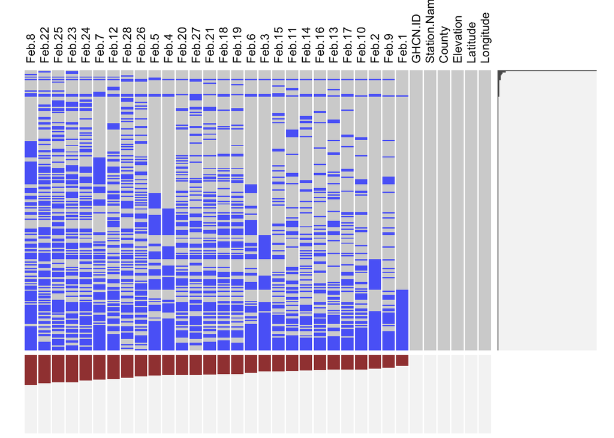

```r
extracat::visna(snow, sort = "b")
```

5. Does the number of missing values vary by county?

Yes

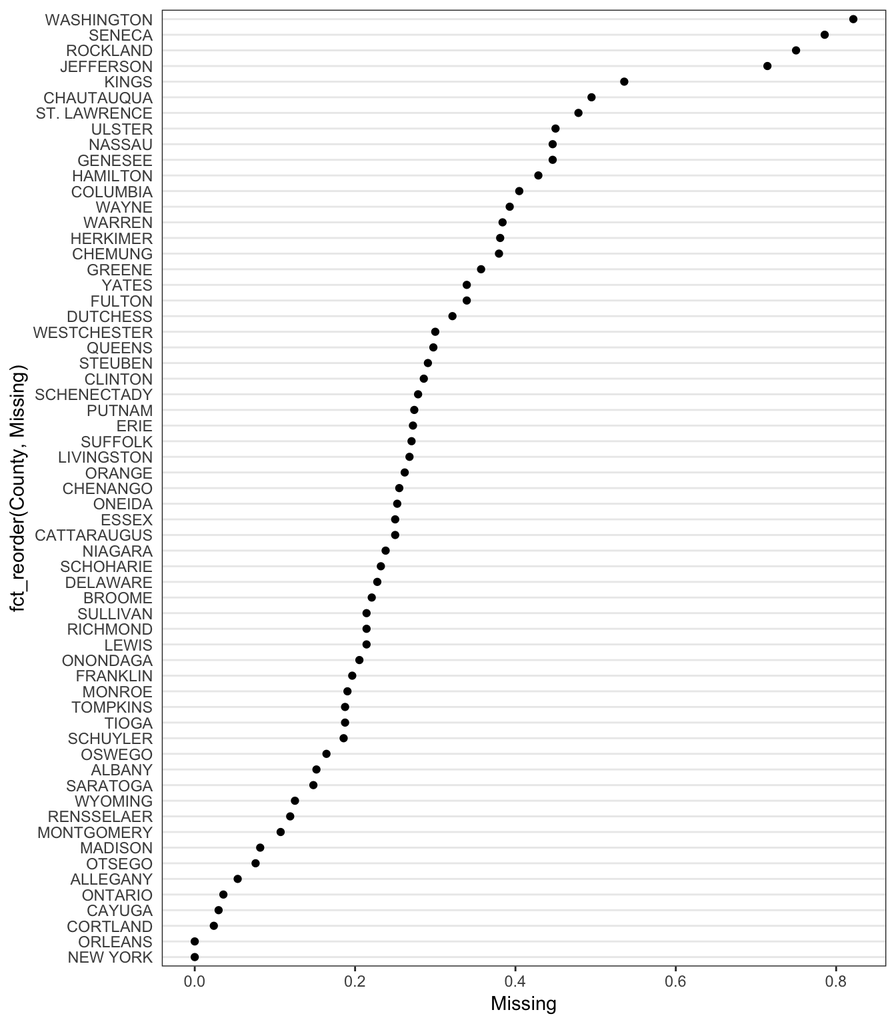

```r
theme_dotplot <- theme_bw() +
  theme(axis.ticks.y = element_blank(),
        panel.grid.major.x = element_blank(),
        panel.grid.major.y = element_line(size = 0.5),
        panel.grid.minor.x = element_blank())


tidysnow <- snow %>%
  select(`Station Name`, County, `Feb 1`:`Feb 28`) %>%
  gather(key = Day, value = Snowfall, -`Station Name`, -County)

tidysnow %>% group_by(County) %>%
  summarize(Missing = sum(is.na(Snowfall))/n()) %>%
  ggplot(aes(Missing, fct_reorder(County, Missing))) +
           geom_point() + theme_dotplot
```

6. Does the number of missing values vary by day of the month?
7. Does the number of missing values vary by type of day (weekday vs weekend)?
8. Does the number of missing values vary by average snowfall?
9. What is your overall conclusion regarding data quality?